# data visualization (qplot)

task 6: create a scatterplot usiing qplot function to show the relationship between the logarithm of carat and the logarithm of the price for a random sample of 100 diamonds

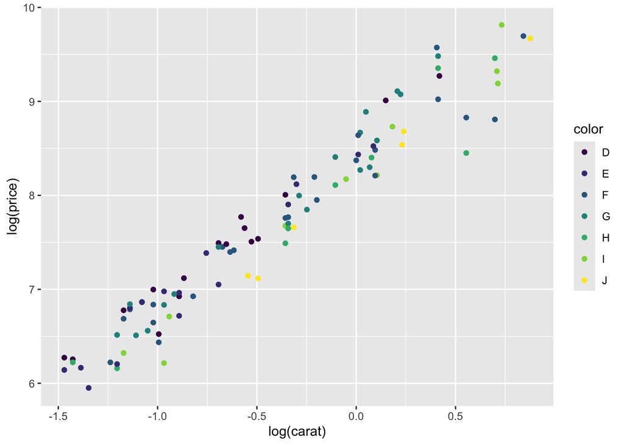

```r
qplot(log(carat),log(price),data=dsmall,colour=color)
```

task 7: create a scatter plot to visualize the relationship between the logarithm of carat weight and the logarithm of price for a random sample of 100 diamonds. The points are colored based on the cut variable

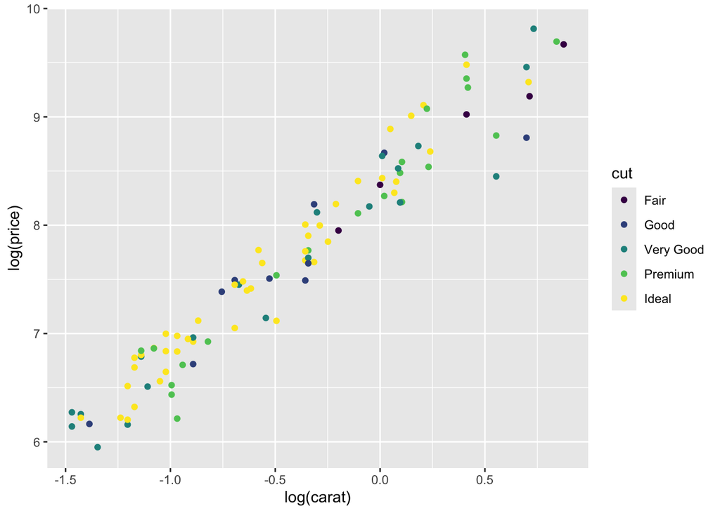

```r
qplot(log(carat),log(price),data = dsmall,colour=cut)
```

#Shape aesthetic

task 8:create a scatter plot to visualize the relationship between the logarithm of carat weight and the logarithm of price for a random sample of 100 diamonds. The points are shaped based on the cut variable

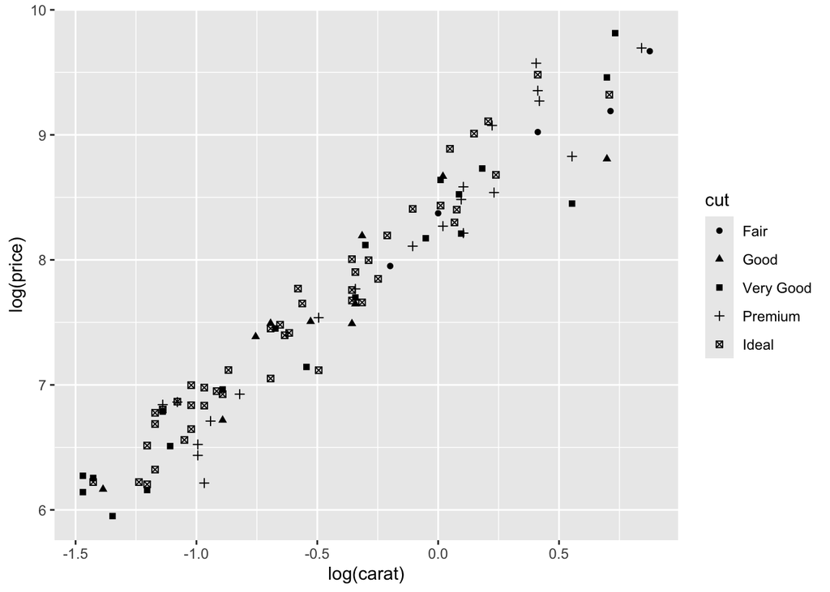

```r
qplot(log(carat),log(price),data = dsmall,shape=cut)
```

#Exercise 1

##a. Apply what you have done previously to dsmall dataset with other aesthetic attribute such as‘size’.

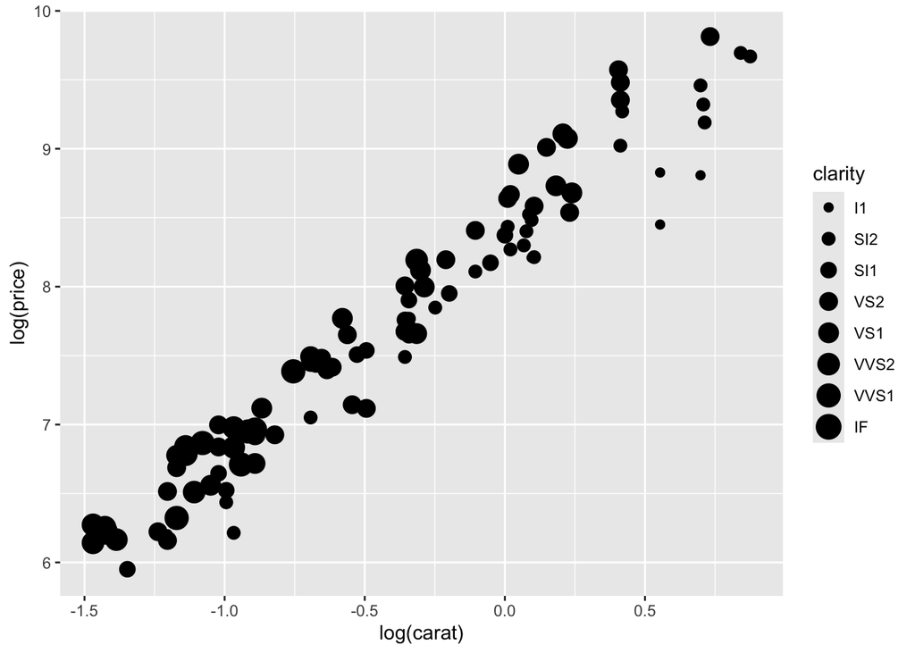

```r
qplot(log(carat),log(price),data = dsmall,size=clarity)
```

```r
#View(diamonds)
```

##Investigate the relationship between other variables (using colour, shape and size aesthetics) to see if you can find interesting information.

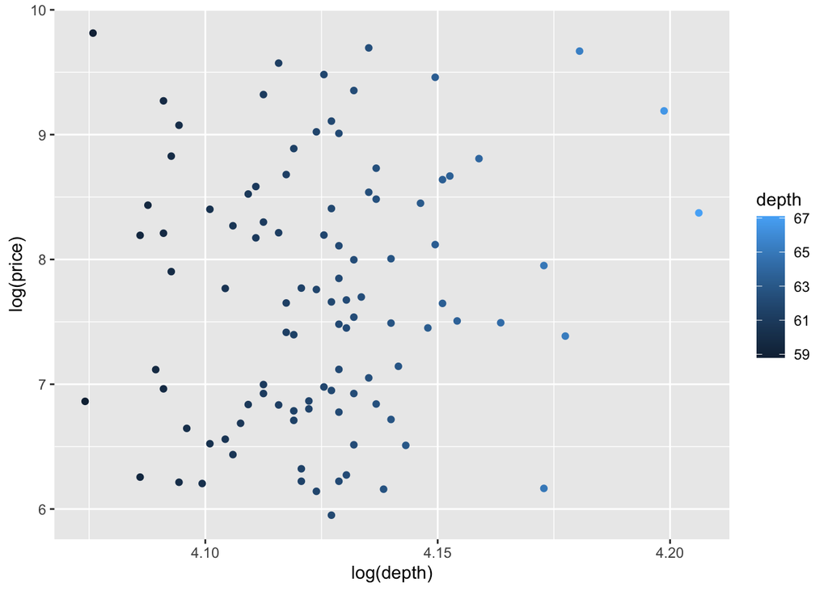

```r
qplot(log(depth),log(price),data = dsmall,colour=depth)
```

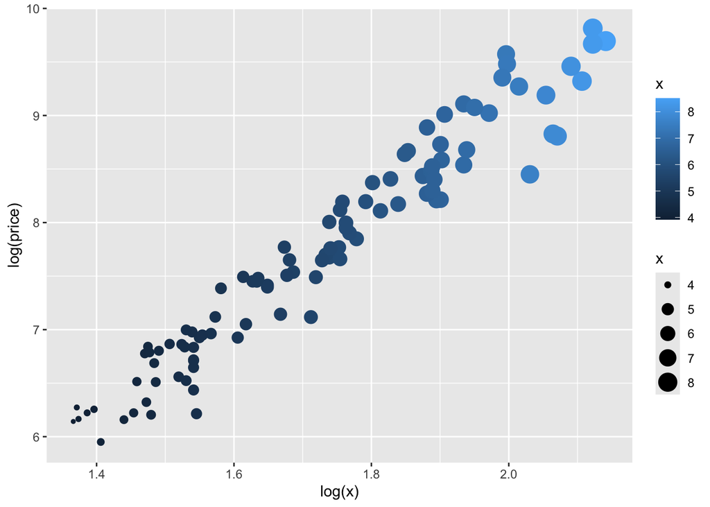

```r
qplot(log(x),log(price),data = dsmall,size=x, colour=x)
```

#Geom 2D You can change the kind of plot by explicitly define geom that “describes the type of object that is used to display the data”

task 9:visualize the relationship between the natural logarithm of carat and price using a line plot.

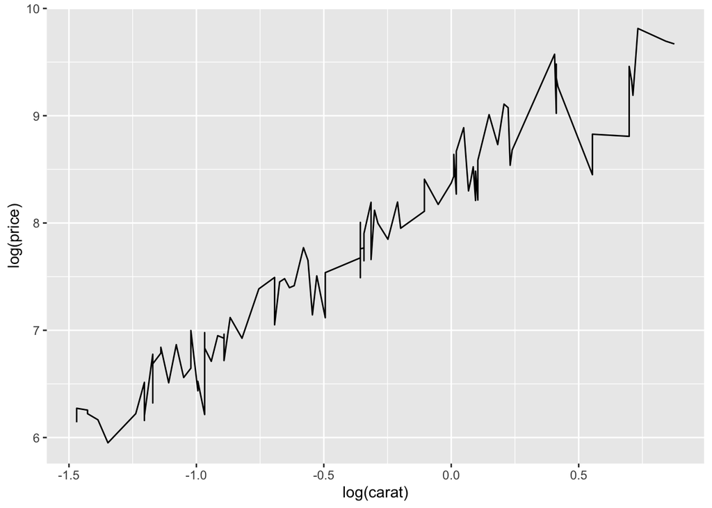

```r
qplot(log(carat),log(price), data = dsmall,geom="line")
```

#Boxplots ans Jitttered

task 10:visualize how the price per carat (price/carat) varies across different color grades (color) of diamonds using a jitter plot

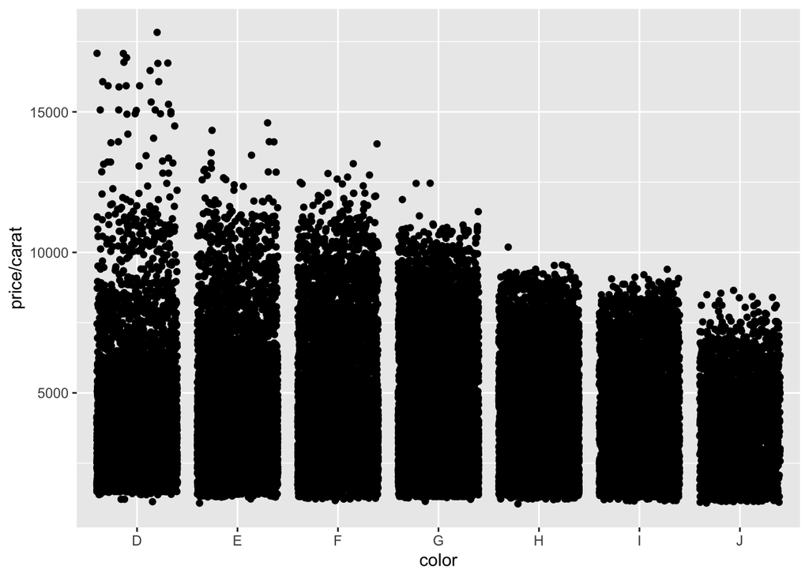

```r
qplot(color,price/carat, data = diamonds, geom = "jitter")
```

task 11: visualize how the price per carat (price/carat) varies across different color grades (color) of diamonds using a boxplot

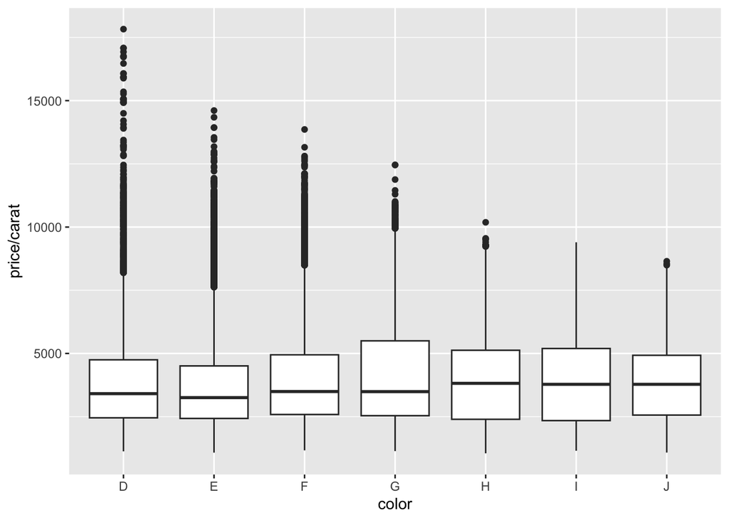

```r
qplot(color,price/carat,data = diamonds,geom = "boxplot")
```

#Geom 1D

task 12:visualize the distribution of diamond carat weights (carat) using a histogram

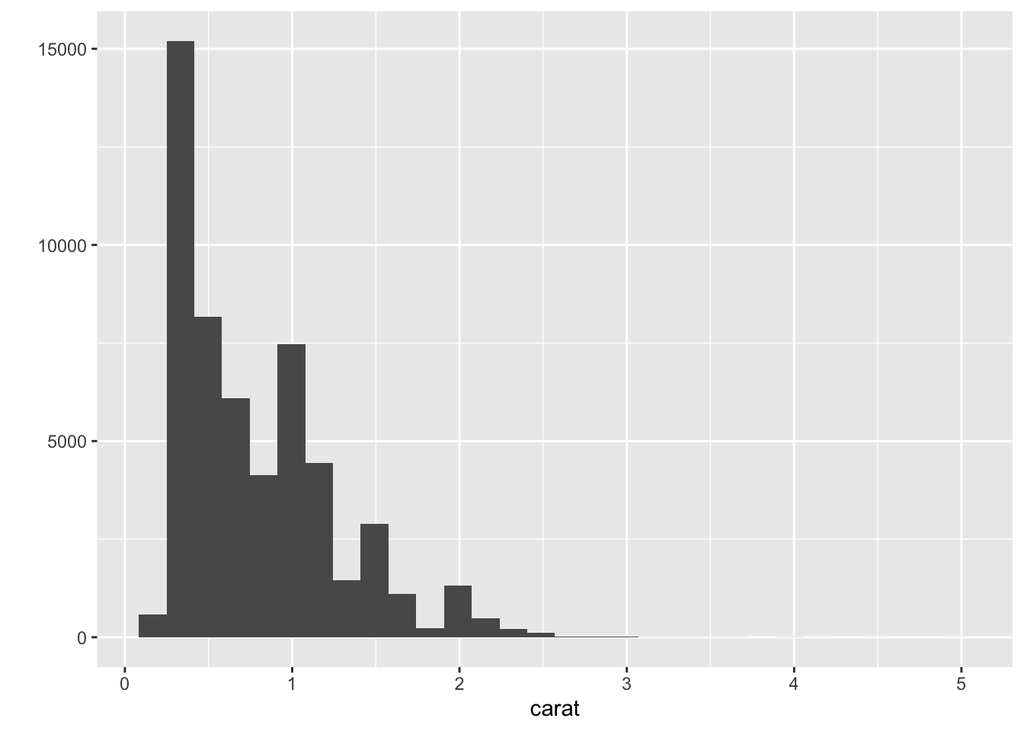

```r
qplot(carat,data = diamonds,geom = "histogram")
```

task 13:visualize the distribution of diamond carat weights (carat) using a density plot

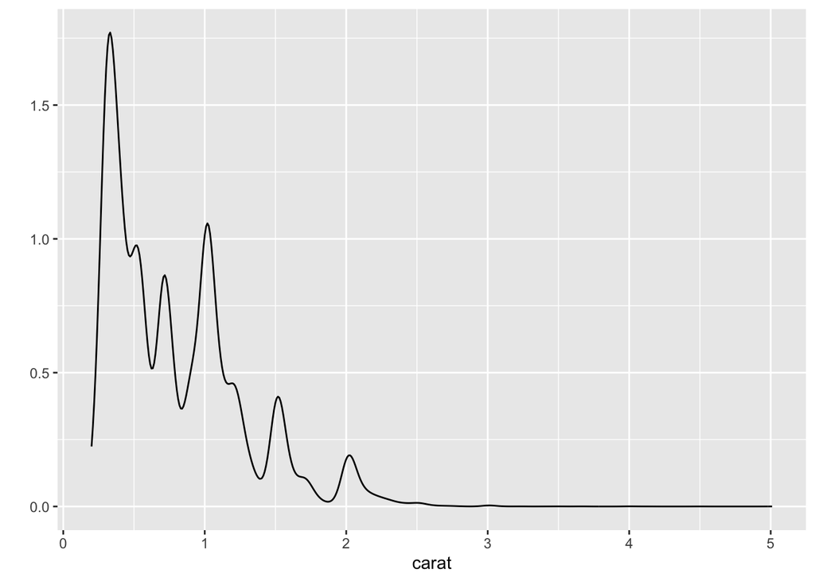

```r
qplot(carat,data = diamonds,geom = "density")
```

task 14:visualize how the distribution of diamond carat weights (carat) varies across different color grades (color) using a density plot

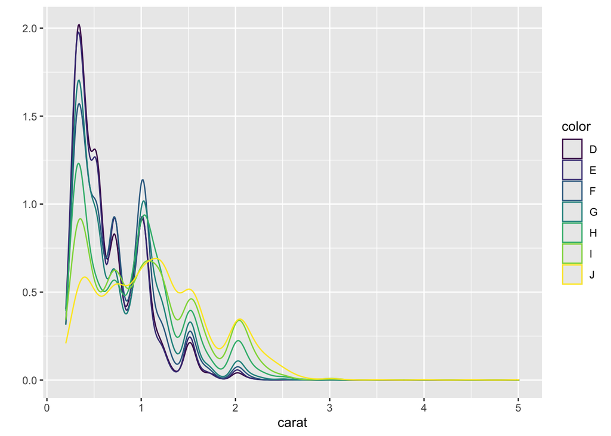

```r
qplot(carat,data = diamonds,geom = "density",colour=color)
```

task 15:The purpose of this code is to visualize how the distribution of diamond carat weights (carat) varies across different color grades (color) using a filled histogram

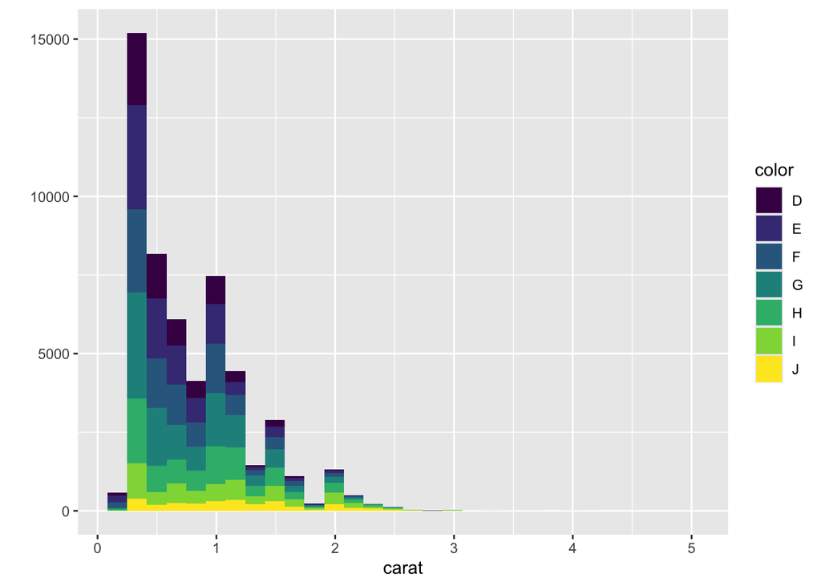

```r
qplot(carat,data = diamonds,geom = "histogram",fill=color)
```

[figure not shown]

```r
qplot(carat,price,data = dsmall,xlab = "Price $", ylab = "Weight (carat)", main = "Price-Weight Relationship")
```

#Exercise 2

##Apply bar geoms to show the colour distribution of diamonds in dsmall dataset to see if you can findinteresting relationships.

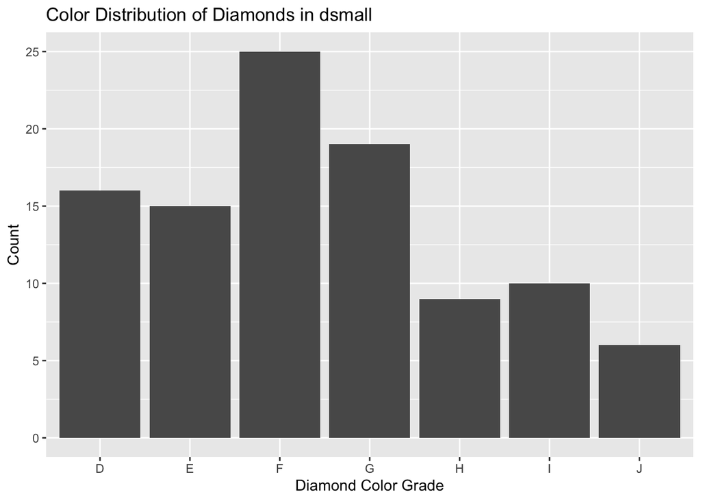

```r
qplot(color,data = dsmall,geom = "bar",xlab="Diamond Color Grade",ylab = "Count",main = "Color Distribution of Diamonds in dsmall")
```